# DA 460 - Assignment 6

Marjorie Blanco

02 August, 2018

# Part 1 R

## Inference for numerical data

```r
# Load the nc data set into our workspace.
download.file("http://www.openintro.org/stat/data/nc.RData", destfile = "nc.RData")
load("nc.RData")
```

### Problem 1

Calculate a 95% confidence interval for the average length of pregnancies (`weeks`) and interpret it in context. Note that since you’re doing inference on a single population parameter, there is no explanatory variable, so you can omit the x variable from the function.

```r
n <- nrow(nc)

# construct the confidence intervals.
lower_vector <- mean(nc$weeks, na.rm = TRUE) - qnorm(.975) * sd(nc$weeks, na.rm = TRUE) / sqrt(n)
upper_vector <- mean(nc$weeks, na.rm = TRUE) + qnorm(.975) * sd(nc$weeks, na.rm = TRUE) / sqrt(n)

# Lower bounds stored in lower_vector, and the upper bounds in upper_vector
c(lower_vector[1], upper_vector[1])
```

```
## [1] 38.15297 38.51637
```

```r
inference(y = nc$weeks, est = "mean", type = "ci", null = 0, alternative = "twosided", method = "theoretical")
```

```
## Single mean
## Summary statistics:
```

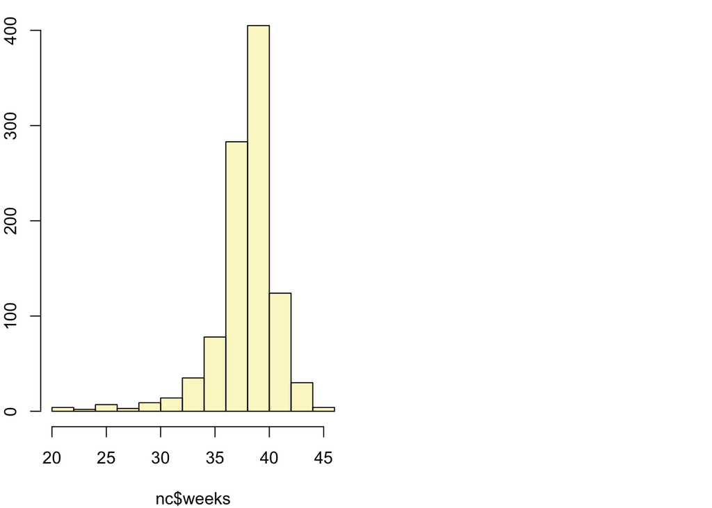

```
## mean = 38.3347 ;  sd = 2.9316 ;  n = 998
## Standard error = 0.0928
## 95 % Confidence interval = ( 38.1528 , 38.5165 )
```

We are 95% confident that the population parameter (for average length of pregnancies) is between 38.1528 and 38.5165.

### Problem 2

Calculate a new confidence interval for the same parameter at the 90% confidence level. You can change the confidence level by adding a new argument to the function: conflevel = 0.90.

```r
n <- nrow(nc)

# construct the confidence intervals.
lower_vector <- mean(nc$weeks, na.rm = TRUE) - qnorm(.95) * sd(nc$weeks, na.rm = TRUE) / sqrt(n)
upper_vector <- mean(nc$weeks, na.rm = TRUE) + qnorm(.95) * sd(nc$weeks, na.rm = TRUE) / sqrt(n)

# Lower bounds stored in lower_vector, and the upper bounds in upper_vector
c(lower_vector[1], upper_vector[1])
```

```
## [1] 38.18219 38.48715
```

```r
inference(y = nc$weeks, est = "mean", type = "ci", conflevel = 0.90, null = 0, alternative = "twosided", method = "theoretical")
```

```
## Single mean
## Summary statistics:
```

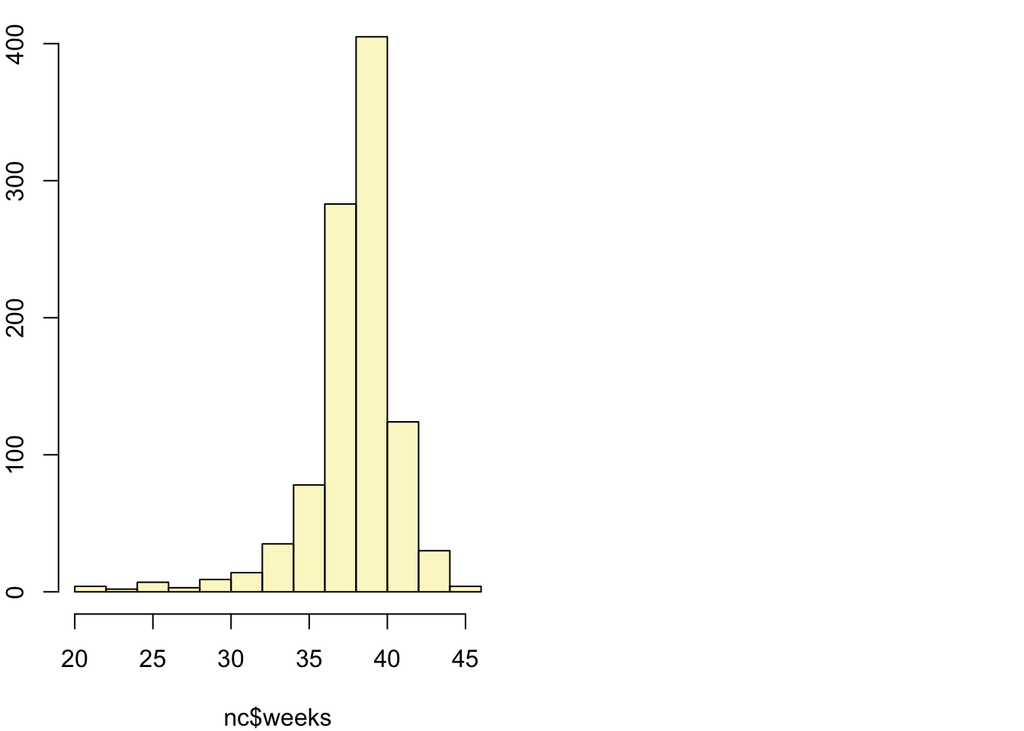

```
## mean = 38.3347 ;  sd = 2.9316 ;  n = 998
## Standard error = 0.0928
## 90 % Confidence interval = ( 38.182 , 38.4873 )
```

We are 90% confident that the population parameter (for average length of pregnancies) is between 38.182 and 38.4873.

### Problem 3

Conduct a hypothesis test evaluating whether the average weight gained by younger mothers is different than the average weight gained by mature mothers.

H0: mu_gained_youngmom - mu_gained_maturemom = 0

Average weight gained by younger mothers is same as the average weight gained by mature mothers.

HA: mu_gained_youngmom - mu_gained_maturemom != 0

Average weight gained by younger mothers is different than the average weight gained by mature mothers.

```r
youngmom <- nc[nc$mature == "younger mom", "gained"]
maturemom <- nc[nc$mature == "mature mom", "gained"]

# construct the confidence intervals.
lower_vector <- mean(youngmom, na.rm = TRUE) - qnorm(.95) * sd(youngmom, na.rm = TRUE) / sqrt(n)
upper_vector <- mean(youngmom, na.rm = TRUE) + qnorm(.95) * sd(youngmom, na.rm = TRUE) / sqrt(n)

# Lower bounds stored in lower_vector, and the upper bounds in upper_vector
c(lower_vector[1], upper_vector[1])
```

```
## [1] 29.81417 31.30668
```

```r
# construct the confidence intervals.
lower_vector <- mean(maturemom, na.rm = TRUE) - qnorm(.95) * sd(maturemom, na.rm = TRUE) / sqrt(n)
upper_vector <- mean(maturemom, na.rm = TRUE) + qnorm(.95) * sd(maturemom, na.rm = TRUE) / sqrt(n)

# Lower bounds stored in lower_vector, and the upper bounds in upper_vector
c(lower_vector[1], upper_vector[1])
```

```
## [1] 28.08941 29.49198
```

```r
inference(y = nc$gained, x = nc$mature, est = "mean", type = "ht", null = 0,
          alternative = "twosided", method = "theoretical", order = c("younger mom","mature mom"))
```

```
## Response variable: numerical, Explanatory variable: categorical
## Difference between two means
## Summary statistics:
## n_younger mom = 844, mean_younger mom = 30.5604, sd_younger mom = 14.3469
## n_mature mom = 129, mean_mature mom = 28.7907, sd_mature mom = 13.4824
```

```
## Observed difference between means (younger mom-mature mom) = 1.7697
##
## H0: mu_younger mom - mu_mature mom = 0
## HA: mu_younger mom - mu_mature mom != 0
## Standard error = 1.286
## Test statistic: Z =  1.376
## p-value =  0.1686
```

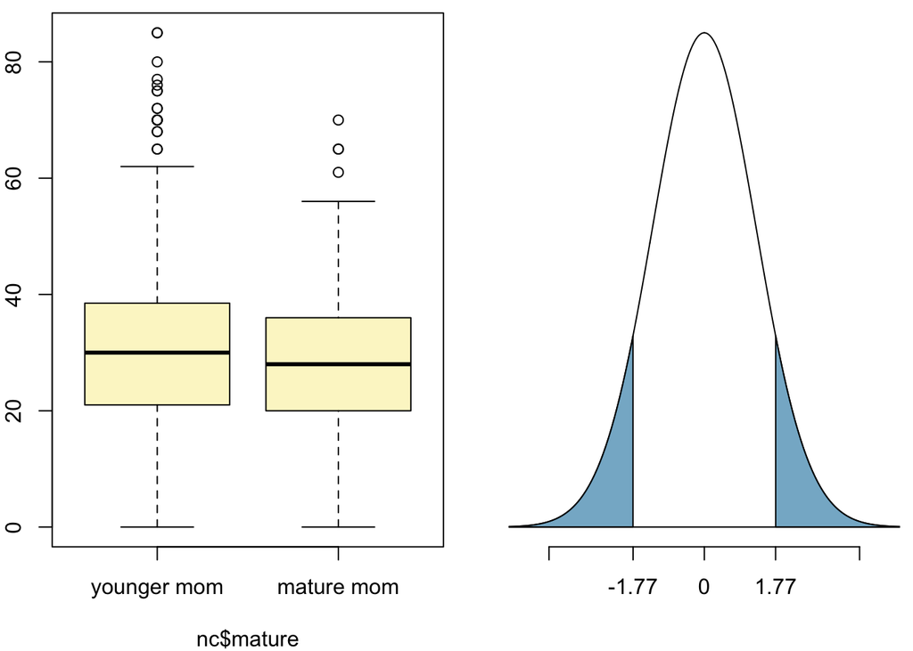

Since p-value is > 0.05 we fail to reject null hypothesis; the average weight gained by mature women is not different that the average weight gained by younger mothers.

### Problem 4

Now, a non-inference task: Determine the age cutoff for younger and mature mothers. Use a method of your choice, and explain how your method works.

```r
by(nc$mage, nc$mature, summary)
```

```
## nc$mature: mature mom
##    Min. 1st Qu.  Median    Mean 3rd Qu.    Max.
##   35.00   35.00   37.00   37.18   38.00   50.00
## --------------------------------------------------------
## nc$mature: younger mom
##    Min. 1st Qu.  Median    Mean 3rd Qu.    Max.
##   13.00   21.00   25.00   25.44   30.00   34.00
```

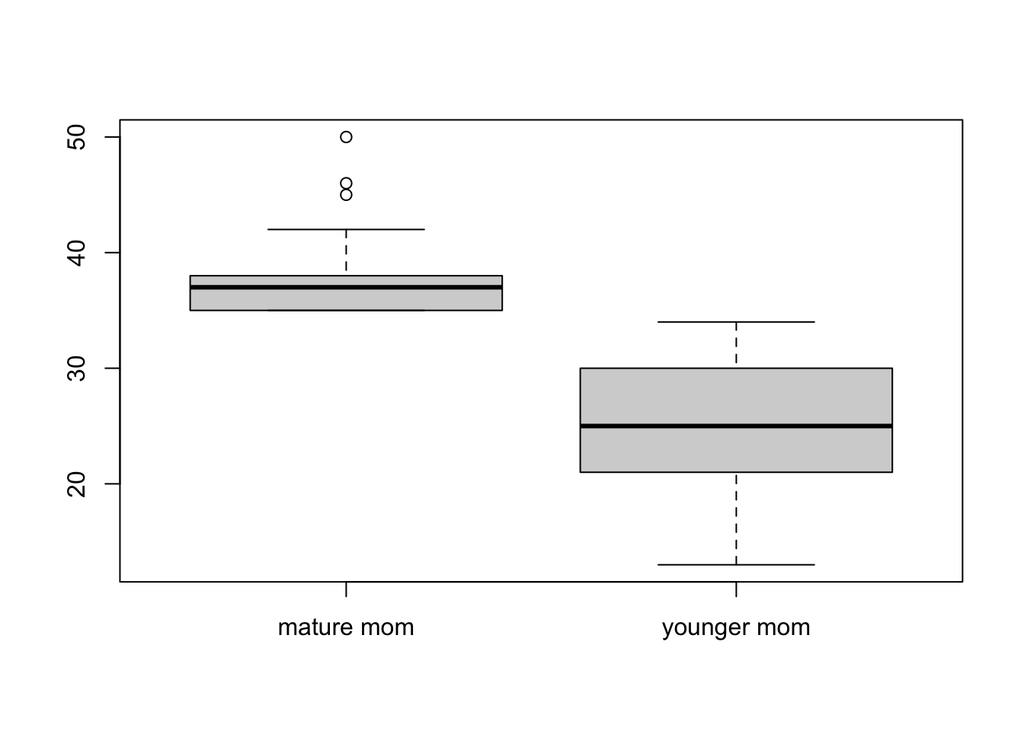

```r
boxplot(nc$mage ~ nc$mature, col="lightgray")
```

```r
inference(y = nc$gained, x = nc$mature, est = "mean", type = "ht", null = 0,
          alternative = "twosided", method = "theoretical", order = c("younger mom","mature mom"))
```

```
## Response variable: numerical, Explanatory variable: categorical
## Difference between two means
## Summary statistics:
## n_younger mom = 844, mean_younger mom = 30.5604, sd_younger mom = 14.3469
## n_mature mom = 129, mean_mature mom = 28.7907, sd_mature mom = 13.4824
```

```
## Observed difference between means (younger mom-mature mom) = 1.7697
##
## H0: mu_younger mom - mu_mature mom = 0
## HA: mu_younger mom - mu_mature mom != 0
## Standard error = 1.286
## Test statistic: Z =  1.376
## p-value =  0.1686
```

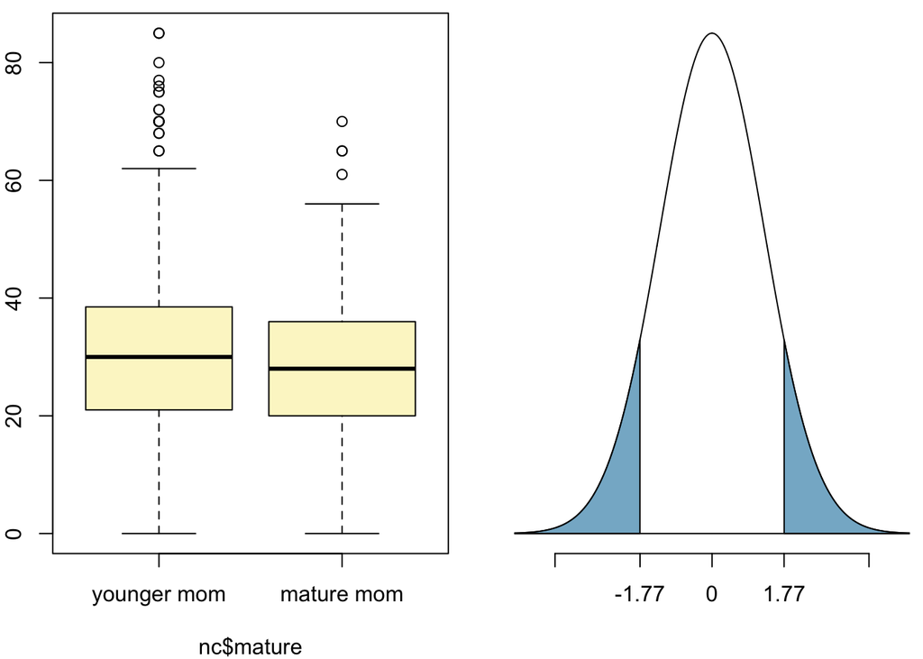

Younger mom’s age cutoff: 13 years old to 34 years old.

Mature mom’s age cutoff: 35 years old to 50 years old.

Since p-value is > 0.05 we fail to reject null hypothesis; the average weight gained by mature women is not different that the average weight gained by younger. mothers.

Method used the function by() and boxplot. The summary function is execute for mother’s age grouped by mature.

### Problem 5

Pick a pair of numerical and categorical variables and come up with a research question evaluating the relationship between these variables. Formulate the question in a way that it can be answered using a hypothesis test and/or a confidence interval. Answer your question using the inference function, report the statistical results, and also provide an explanation in plain language.

Does the mother’s age has an prevalence on low birth weight?

H0: mu_mage_lowbirthweight - mu_mage_notlowbirthweight = 0

Mother’s age has no prevalence in low birth weight.

HA: mu_mage_lowbirthweight - mu_mage_notlowbirthweight != 0

Mother’s age has prevalence in low birth weight.

```r
inference(y = nc$mage, x = nc$lowbirthweight, est = "mean", type = "ht", null = 0,
          alternative = "twosided", method = "theoretical")
```

```
## Response variable: numerical, Explanatory variable: categorical
## Difference between two means
## Summary statistics:
## n_low = 111, mean_low = 26.964, sd_low = 6.7755
## n_not low = 889, mean_not low = 27.0045, sd_not low = 6.1439
```

```
## Observed difference between means (low-not low) = -0.0405
##
## H0: mu_low - mu_not low = 0
## HA: mu_low - mu_not low != 0
## Standard error = 0.675
## Test statistic: Z =  -0.06
## p-value =  0.9522
```

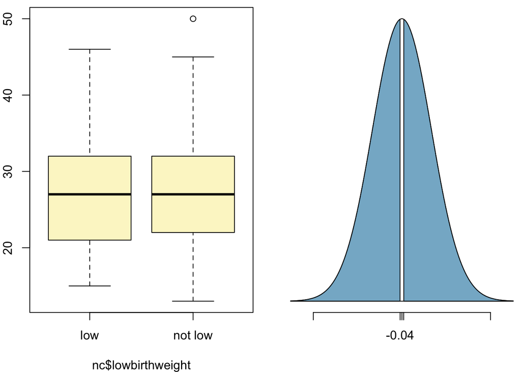

Since p-value is > 0.05 we fail to reject null hypothesis; the average mother’s age has no prevalence in low birth weight.

Does the father’s age has an prevalence on low birth weight?

H0: mu_fage_lowbirthweight - mu_fage_notlowbirthweight = 0

Father’s age has no prevalence in low birth weight.

HA: mu_fage_lowbirthweight - mu_fage_notlowbirthweight != 0

Father’s age has prevalence in low birth weight.

```r
inference(y = nc$fage, x = nc$lowbirthweight, est = "mean", type = "ht", null = 0,
          alternative = "twosided", method = "theoretical")
```

```
## Response variable: numerical, Explanatory variable: categorical
## Difference between two means
## Summary statistics:
## n_low = 81, mean_low = 30.3086, sd_low = 7.8988
## n_not low = 748, mean_not low = 30.25, sd_not low = 6.6353
```

```
## Observed difference between means (low-not low) = 0.0586
##
## H0: mu_low - mu_not low = 0
## HA: mu_low - mu_not low != 0
## Standard error = 0.911
## Test statistic: Z =  0.064
## p-value =  0.9486
```

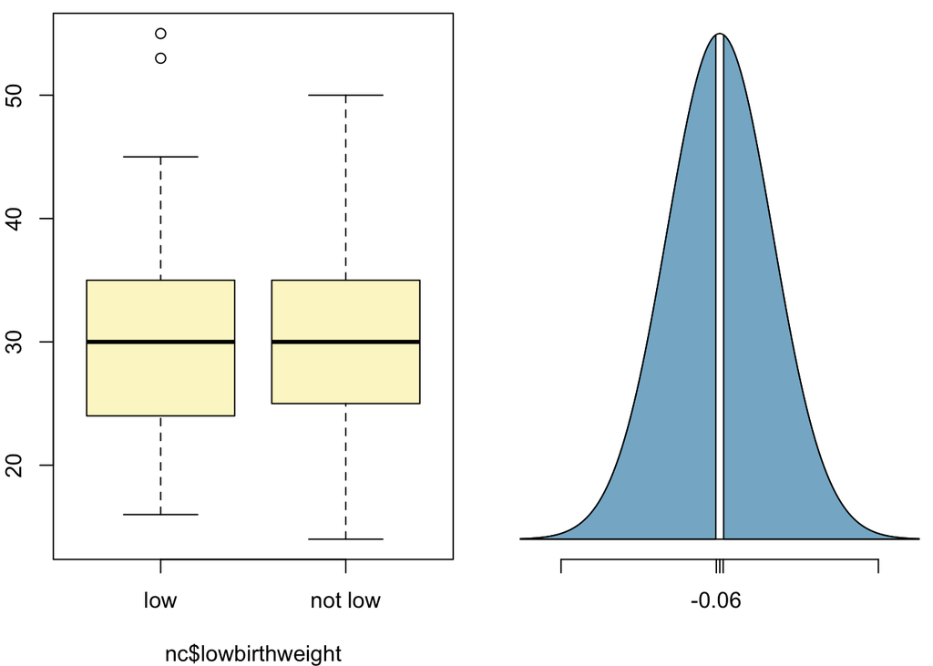

Since p-value is > 0.05 we fail to reject null hypothesis; the average father’s age has no prevalence in low birth weight.

## Inference for categorical data

```r
download.file("http://www.openintro.org/stat/data/atheism.RData", destfile = "atheism.RData")
load("atheism.RData")
```

### Problem 6

Answer the following two questions using the inference function. As always, write out the hypotheses for any tests you conduct and outline the status of the conditions for inference. a. Is there convincing evidence that Spain has seen a change in its atheism index between 2005 and 2012? Hint: Create a new data set for respondents from Spain. Then use their responses as the first input on the inference, and use year as the grouping variable.

H0: There is no convincing evidence that Spain has seen a change in its atheism index between 2005 and 2012

H0: p2005 - p2012 = 0

HA: There is convincing evidence that Spain has seen a change in its atheism index between 2005 and 2012

HA: p2005 - p2012 != 0

```r
spain05 <- subset(atheism, nationality == "Spain" & year == "2005")
pspain05athe <- count(spain05$response == 'atheist')
names(pspain05athe) <- c("atheist", "total")
pspain05athe$percent <- pspain05athe$total / sum(pspain05athe$total) * 100
kable(pspain05athe)
```

| atheist | total | percent |
| --- | --- | --- |
| FALSE | 1031 | 89.9651 |
| TRUE | 115 | 10.0349 |

```r
inference(spain05$response, est = "proportion", type = "ci", method = "theoretical",
          success = "atheist")
```

```
## Single proportion -- success: atheist
## Summary statistics:
```

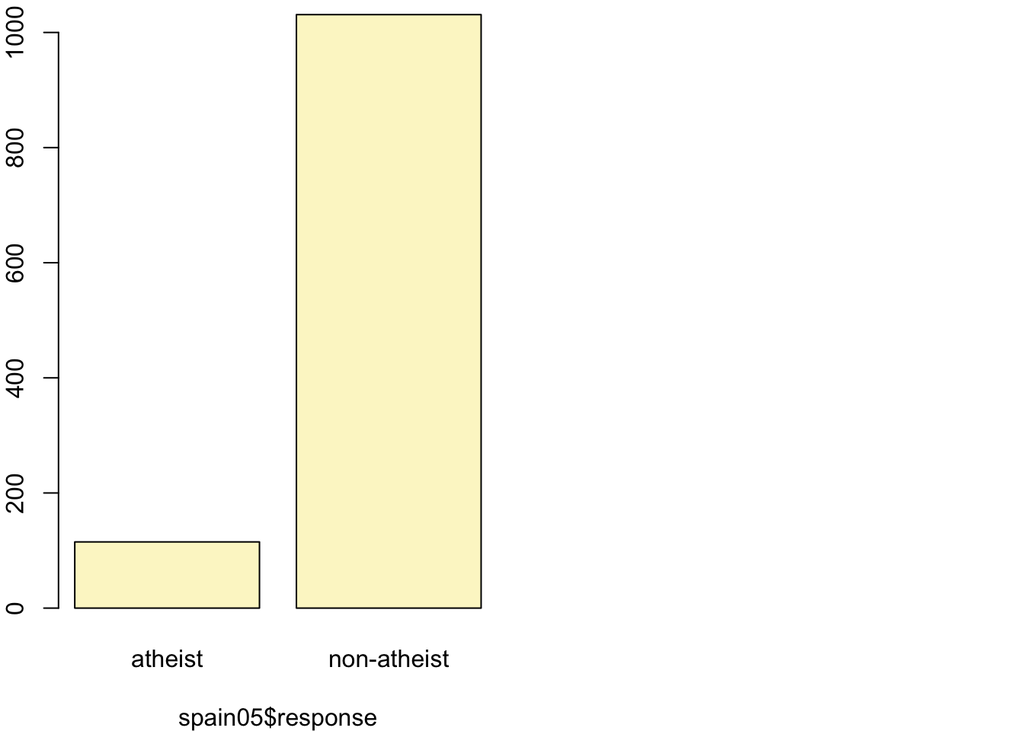

```
## p_hat = 0.1003 ;  n = 1146
## Check conditions: number of successes = 115 ; number of failures = 1031
## Standard error = 0.0089
## 95 % Confidence interval = ( 0.083 , 0.1177 )
```

The 95% confidence interval for Spain 2005 is: ( 0.083 , 0.1177 ).

```r
spain12 <- subset(atheism, nationality == "Spain" & year == "2012")
pspain12athe <- count(spain12$response == 'atheist')
names(pspain12athe) <- c("atheist", "total")
pspain12athe$percent <- pspain12athe$total / sum(pspain12athe$total) * 100
kable(pspain12athe)
```

| atheist | total | percent |
| --- | --- | --- |
| FALSE | 1042 | 91.004367 |
| TRUE | 103 | 8.995633 |

```r
inference(spain12$response, est = "proportion", type = "ci", method = "theoretical",
          success = "atheist")
```

```
## Single proportion -- success: atheist
## Summary statistics:
```

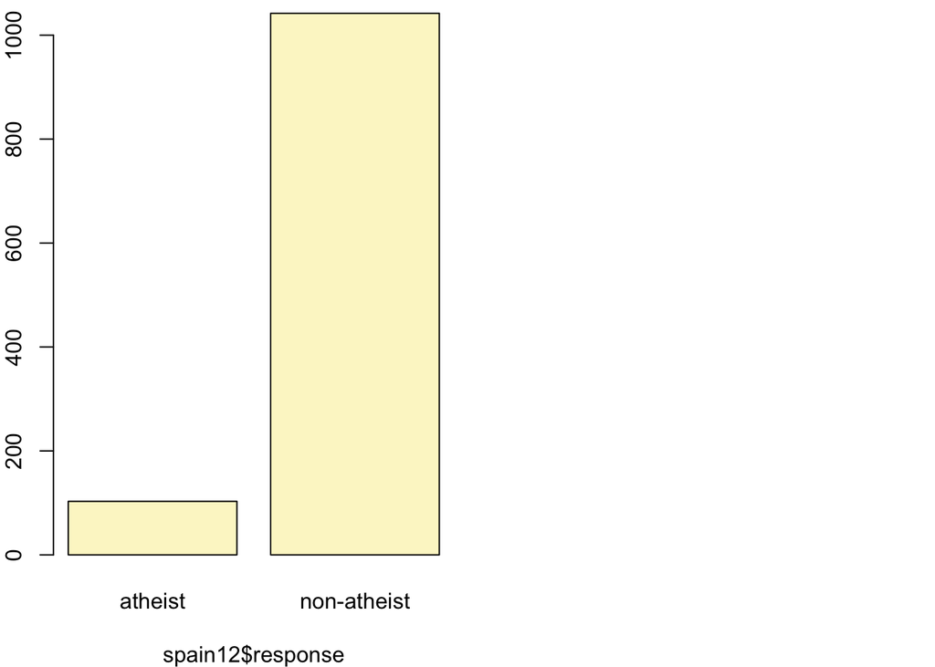

```
## p_hat = 0.09 ;  n = 1145
## Check conditions: number of successes = 103 ; number of failures = 1042
## Standard error = 0.0085
## 95 % Confidence interval = ( 0.0734 , 0.1065 )
```

The 95% confidence interval for Spain 2012 is: ( 0.0734 , 0.1065 ).

```r
spain <- subset(atheism, nationality == "Spain" & year == "2005"  | nationality == "Spain" & year == "2012")

inference(y = spain$response, x = as.factor(spain$year), est = "proportion", type = "ht", null = 0, alternative = "twosided", method = "theoretical", success = "atheist")
```

```
## Response variable: categorical, Explanatory variable: categorical
## Two categorical variables
## Difference between two proportions -- success: atheist
## Summary statistics:
##              x
## y             2005 2012  Sum
##   atheist      115  103  218
##   non-atheist 1031 1042 2073
##   Sum         1146 1145 2291
```

```
## Observed difference between proportions (2005-2012) = 0.0104
##
## H0: p_2005 - p_2012 = 0
## HA: p_2005 - p_2012 != 0
## Pooled proportion = 0.0952
## Check conditions:
##    2005 : number of expected successes = 109 ; number of expected failures = 1037
##    2012 : number of expected successes = 109 ; number of expected failures = 1036
## Standard error = 0.012
## Test statistic: Z =  0.848
## p-value =  0.3966
```

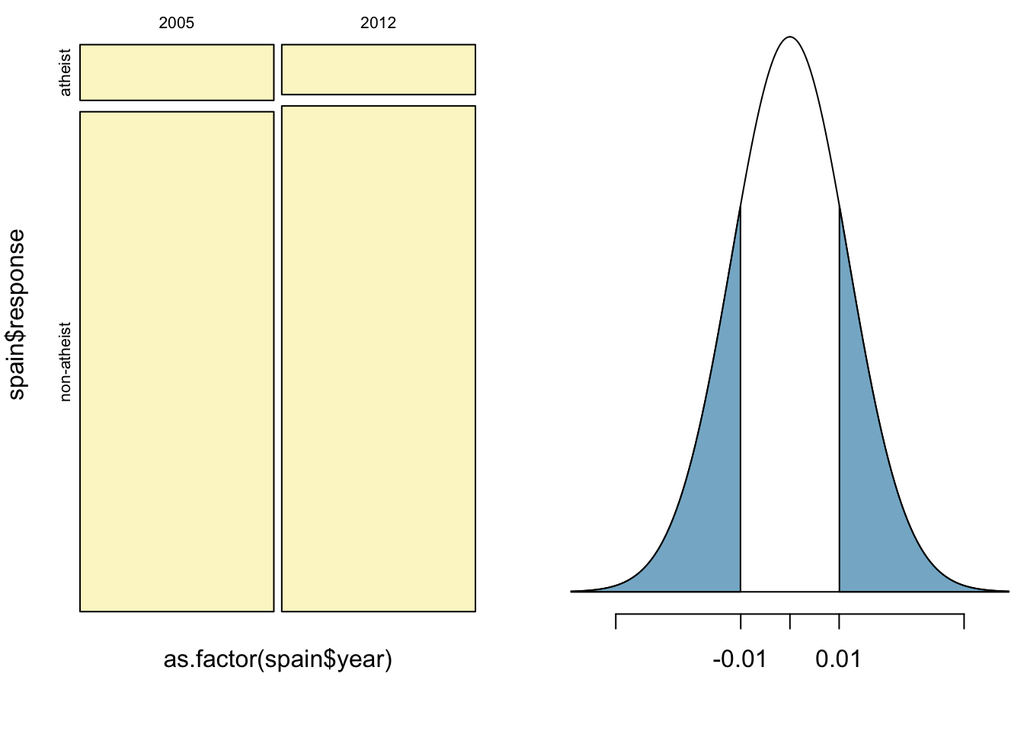

The confidence interval does overlap; therefore there is no convincing evidence that the atheism index between 2005 and 2012 have changed significantly.

2. Is there convincing evidence that the United States has seen a change in its atheism index between 2005 and 2012?

H0: There is no convincing evidence that United States has seen a change in its atheism index between 2005 and 2012

H0: p2005 - p2012 = 0

HA: There is convincing evidence that United States has seen a change in its atheism index between 2005 and 2012

HA: p2005 - p2012 != 0

```r
us05 <- subset(atheism, nationality == "United States" & year == "2005")
pus05athe <- count(us05$response == 'atheist')
names(pus05athe) <- c("atheist", "total")
pus05athe$percent <- pus05athe$total / sum(pus05athe$total) * 100
kable(pus05athe)
```

| atheist | total | percent |
| --- | --- | --- |
| FALSE | 992 | 99.001996 |
| TRUE | 10 | 0.998004 |

```r
inference(us05$response, est = "proportion", type = "ci", method = "theoretical",
          success = "atheist")
```

```
## Single proportion -- success: atheist
## Summary statistics:
```

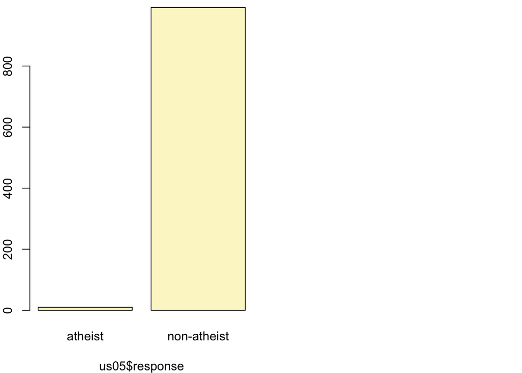

```
## p_hat = 0.01 ;  n = 1002
## Check conditions: number of successes = 10 ; number of failures = 992
## Standard error = 0.0031
## 95 % Confidence interval = ( 0.0038 , 0.0161 )
```

The 95% confidence interval for United States 2005 is: ( 0.0038 , 0.0161 ).

```r
us12 <- subset(atheism, nationality == "United States" & year == "2012")
pus12athe <- count(us12$response == 'atheist')
names(pus12athe) <- c("atheist", "total")
pus12athe$percent <- pus12athe$total / sum(pus12athe$total) * 100
kable(pus12athe)
```

| atheist | total | percent |
| --- | --- | --- |
| FALSE | 952 | 95.00998 |
| TRUE | 50 | 4.99002 |

```r
inference(us12$response, est = "proportion", type = "ci", method = "theoretical",
          success = "atheist")
```

```
## Single proportion -- success: atheist
## Summary statistics:
```

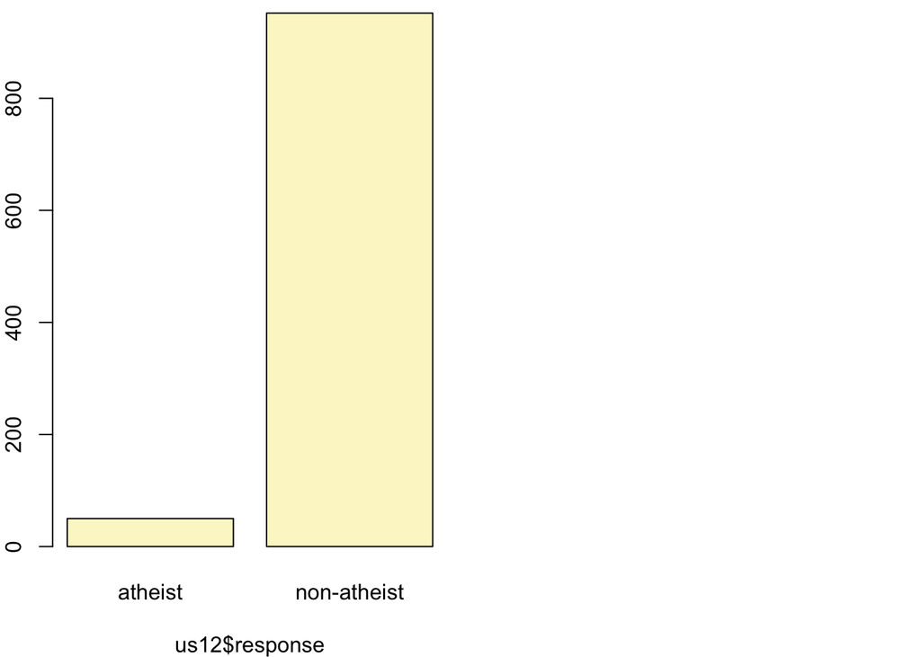

```
## p_hat = 0.0499 ;  n = 1002
## Check conditions: number of successes = 50 ; number of failures = 952
## Standard error = 0.0069
## 95 % Confidence interval = ( 0.0364 , 0.0634 )
```

The 95% confidence interval for United States 2012 is: ( 0.0364 , 0.0634 ).

```r
spain <- subset(atheism, nationality == "United States" & year == "2005"  | nationality == "United States" & year == "2012")

inference(y = spain$response, x = as.factor(spain$year), est = "proportion", type = "ht", null = 0, alternative = "twosided", method = "theoretical", success = "atheist")
```

```
## Response variable: categorical, Explanatory variable: categorical
## Two categorical variables
## Difference between two proportions -- success: atheist
## Summary statistics:
##              x
## y             2005 2012  Sum
##   atheist       10   50   60
##   non-atheist  992  952 1944
##   Sum         1002 1002 2004
```

```
## Observed difference between proportions (2005-2012) = -0.0399
##
## H0: p_2005 - p_2012 = 0
## HA: p_2005 - p_2012 != 0
## Pooled proportion = 0.0299
## Check conditions:
##    2005 : number of expected successes = 30 ; number of expected failures = 972
##    2012 : number of expected successes = 30 ; number of expected failures = 972
## Standard error = 0.008
## Test statistic: Z =  -5.243
## p-value =  0
```

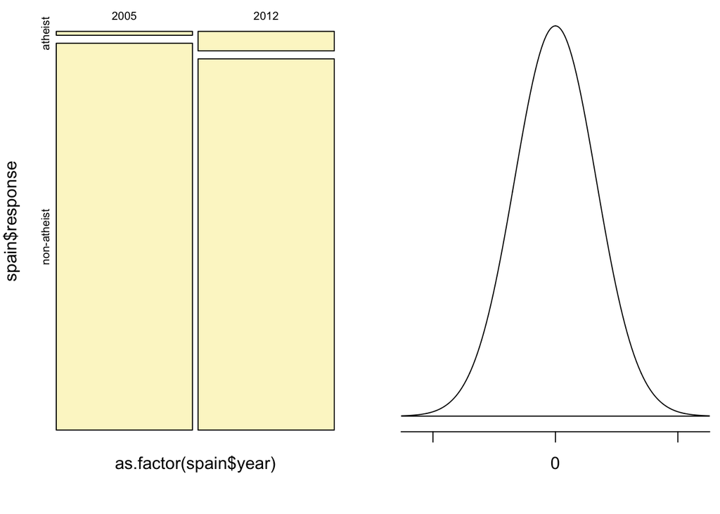

The confidence interval does not overlap; therefore there isconvincing evidence that the atheism index between 2005 and 2012 have changed significantly.

### Problem 7

If in fact there has been no change in the atheism index in the countries listed in Table 4, in how many of those countries would you expect to detect a change (at a significance level of 0.05) simply by chance?

A Type 1 Error is rejecting the null hypothesis when H0 is actually true. We want to avoid incorrectly rejecting H0 more than 5% of the time. There are 39 countries in Table 4, therefore we expect no more than 2 countries to change just by chance.

### Problem 8

Suppose you’re hired by the local government to estimate the proportion of residents that attend a religious service on a weekly basis. According to the guidelines, the estimate must have a margin of error no greater than 1% with 95% confidence. You have no idea what to expect for p. How many people would you have to sample to ensure that you are within the guidelines? Hint: Refer to your plot of the relationship between pp and margin of error. Do not use the data set to answer this question.

```r
p <- 0.5         # margin of error is largest when p is equal to 0.5
ME <- .01        # margin of error no greater than 1%
Z <- qnorm(.975) # 95% Confidence or alpha = 0.05

# Margin of Error = Z * standard of error
# Standard of error = Margin of Error/Z
SE <- ME/Z

# Standard of error <- sqrt(p*(1-p)/n)
# Rearrange for n. n = (p*(1-p))/(standard of error)^2
n <- (p * (1-p))/SE^2
paste("Sample Needed: ", n)
```

```
## [1] "Sample Needed:  9603.64705173531"
```